# Notes on Machine Learning Foundations

Yang Ge

September 28, 2015

# Week 2

## 1. When can machine learn?

### Hypothesis: ‘perceptron’

Each “tall” $w$ represents a hypothesis $h$ and multiply the “tall” $x$.

Perceptron is equivalent to linear (binary) classifier.

### Perceptron Learning Algorithm

want g is close to f (hard when *f* unknow)

Ideally, $g(x_n) = f(x_n) = y_n$

Difficulty: H is infinite space.

Idea: start from some g0, and correct its mistakes on D.

Algorithm:

1. Find a mistakes $x_n(t)$
2. Updates $w(t+1) <- w(t) + y_n(t)x_n(t)$

Geometric explaination: if the angle between w and x is too big, we make it smaller, otherwise, make it bigger.

A fault confessed is half redressed.

## Guarantee of PLA

The normalized inner product of w_f and w_t will increase monotonously. It will stop at certain iteration.

## Non separable data

Pros: simple to implement, fast, work for any dimension d. Cons: * Assume linearly separable. * not fully sure how long halting takes (rho depends on wf)

PLA Algorithm

Run enough iteration.

# Types of Learning

## Learning with different output space

Binary classification * Credit card approval * Email spam/not spam * Patient sick/not sick * ad profitable/not profitable * answer correct/incorrect

## Learning with different labels

## Learning with different protocols

## Learning with different input space

# Lecture 4, Feasible of Learning

## Learning is impossible?

No free launch!

## Probability to the Rescue

Bin model.

in sample $\nu$ is likely close to unknow $\mu$.

Hoeffding’s Inequality:

*Probably Approximately Correct* (PAC).

## Connection to Learning

Learning.

Unknown **f** target f(x)

h is wrong/orange equivalent h(x) not equals to f(x) h is right/green Check h on D = {(xn, yn)}

### Added components

$E_{in}$: in sample

$E_{out}$: out sample

### The Formal Guarantee

- Valid for all $N$ and $\epsilon$.
- Doesn’t depend on $E_{out}(h)$, $f$ and $P$ can stay unknown.
- $E_{in}(h) = E_{out}(h)$ is PAC.

## Connection to real learning

### Bound of BAD data

If $|\mathcal{H}| = M$ is finite, $N$ large enough, for whatever $g$ picked by $\mathcal{A}$, $E_{out}(g) \approx E_{in}(g)$.

If $\mathcal{A}$ finds one $g$ with $E_{in}(g) \approx 0$, PAC guarantees for $E_{out}(g) \approx 0$.

# Lecture 5 Training v.s. Testing

## Recap and Preview

If $|\mathcal{H}| = M$ is finite, $N$ large enough, for whatever $g$ picked by $\mathcal{A}$, $E_{out}(g) \approx E_{in}(g)$.

If $\mathcal{A}$ finds one $g$ with $E_{in}(g) \approx 0$, PAC guarantees for $E_{out}(g) \approx 0$.

$E_{out}(h) \underbrace{\approx}_{test} E_{in}(h) \underbrace{\approx}_{train} 0$

**Two Central Questions:**

1. Can we make sure that $E_{out}(h)$ is close enough to $E_{in}(g)$?
2. Can we make $E_{in}(g)$ small enough?

What role does $\underbrace{|\mathcal{H}|}_{M}$ play for these two questions?

**Trade-off on $M$**

- small $M$
  1. Yes! $Pr(BAD) \leq 2 \cdot M \cdot exp(\dots)$
  2. No! too few choices!
- large $M$
  1. No! $Pr(BAD) \leq 2 \cdot M \cdot exp(\dots)$ is big.
  2. Yes! many choices
- What if $M = \infty$

**Todo:**

- establish a finite quantity that replaces $M$ $Pr(|E_{in}(g)-E_{out}(g)| > \epsilon) \leq 2 m_{\mathcal{H}} exp(-2 \epsilon^2 N)$
- justify the feasiblity of learning for infinite $M$
- study $m_{\mathcal{H}}$ to understand its trade-off for ‘right’ $\mathcal{H}$

These will be covered in next 3 lectures :-)

## Effective Number of Lines

**Where did M come from**

- *BAD events $B_m$*: $|E_{in}(B_m) - E_{out}(B_m)| > \epsilon$
- To give $\mathcal{A}$ freedom choice, need to bound $Pr(B_1 \cup B_2 \cup \dots B_M)$
- Worse case: all $B_m$ non-overlapping. It fails when M is infinite. $Pr(B_1 \cup B_2 \cup \dots B_M) \leq Pr(B_1) + \dots + Pr(B_M)$

**Where did uniform bound fail?**

- *BAD events $B_m$*: $|E_{in}(B_m) - E_{out}(B_m)| > \epsilon$ overlapping for similar hypothesis $h_1 \approx h_2$
- Why?
  - $E_{out}(h_1) \approx E_{out}(h_2)$
  - for most $D$, $E_{in}(h_1) \approx E_{in}(h_2)$
- union bound *over-estimation*
- Solution: group similar hypothesis by kind.

**How Many lines Are There?**

$\mathcal{H} = {all\ lines\ in\ R^2}$

- how many lines? $\infty$
- how many kinds of lines from $\mathbf{x_1}$ point of view? 2 kinds:
  - $h_1(x_1) = +1$ and $h_2(x_1) = -1$
- how many kinds of lines for 4 points? At most 14.

**Effective Number of Lines**

It means max number of lines w.r.t N inputs $x_1, \dots, x_N$

- must be $\leq 2^N$
- finite ‘grouping’ of infinitely-many lines $\in \mathcal{H}$
- wish:

$Pr(|E_{in}(g)-E_{out}(g)| > \epsilon) \leq 2\ eff(N)\ exp(-2 \epsilon^2 N)$

If

1. eff(N) can replace $M$ and
2. eff(N) << $2^N$

Then learning is possible for infinite lines :-)

## Effective Number of Hypothesis

**Dichotomy: mini hypothesis**

- Definition: hypothesis ‘limited’ to the eyes of $x_1, \dots, x_n$, i.e. $h(x_1, \dots, x_n) = (h(x_1), \dots, h(x_n)) \in \{\times, \circ\}^N$
- Dichotomy set: $\mathcal{H}(x_1, \dots, x_n)$: all dichotomies implemented by $\mathcal{H}$ on $x_1, \dots, x_n$.
- Dichotomy set is bounded by $2^N$, $\mathcal{H}$ can be infinite.
- $|\mathcal{H}(x_1, \dots, x_n)|$ is a candidate for replacing $M$.

**Growth Function**

In order to remove the dependance between the size of dichotomy set and the inputs, define $m_H(N) = max|\mathcal{H}(x_1, \dots, x_n)|$. For example, for PLA, $m_H(1) = 2, m_H(2) = 4, m_H(3) = 8, m_H(4) = 14$.

It is called growth function and bounded by $2^N$.

**Growth Function for Positive Rays**

- $\mathcal{X} = \mathbb{R}$
- $\mathcal{H}$ contains $h$, where each $h(x) = sign(x-1)$ for threshold $a$.
- positive half of 1D perceptrons.
- $m_{\mathcal{H}}(N)=N+1 \ll 2^N$

**Growth Function for Positive Intervals**

- $\mathcal{X} = \mathbb{R}$
- $\mathcal{H}$ contains $h$, where each $h(x) = sign(x-1)$ iff $x \in [l,r)$, -1 otherwise. $m_{\mathcal{H}}(N) = \binom{N+1}{2} + 1 = \frac{N^2}{2} + \frac{N}{2} + 1 \ll 2^N$

**Growth Function for convex set**

- If $x_1, \dots, x_n$ on a big circle, then every dichotomy can be implemented. $m_{\mathcal{H}}(N) = 2^N$
- call those $N$ inputs ‘shattered’ by $\mathcal{H}$.

## Break Point

**The 4 growth functions**

- positive ray, $m_{\mathcal{H}}(N)=N+1$
- postitive intervals, $\frac{N^2}{2} + \frac{N}{2} + 1$
- convex set, $2^N$
- 2D perceptrons: $m_{\mathcal{H}}(N) < 2^N$ in some cases

Can we replace $M$ by $\mathcal{H}$? Polynomial good, exponential bad…

$Pr(|E_{in}(g)-E_{out}(g)| > \epsilon) \overset{?}{\leq} 2\ m_{\mathcal{H}}(N) \ exp(-2 \epsilon^2 N)$

**Break point of**

- three inputs: ‘exists’ shatter; for inputs, ‘for all’ no shatter
- if no $k$ inputs can be shattered by $\mathcal{H}$, the $k$ is a break point.
- Any $k+i$ is break points.
- conjecture: break point $k$, $m_{\mathcal{H}}(N) = O(N^{k-1})$

## Conclusion

- Recap and Preview:
  - two questions, $E_{out} \approx E_{in}$ and $E_{in}(g) \approx 0$
- Effective No. of lines
- Effective No. of Hypothesis
- Break point
  - When $m_{\mathcal{H}}$ becomes non-exponential

# Lecture 6 Theory of Generalization

## Restriction of Break Point

- max possible $m_{\mathcal{H}}$ when $N=3$ and $k=2$
  - 4 dichotomies, shatter two points, no, but 5 yes.
- break point $k$ restricts maximum possible $m_{\mathcal{H}}$ a lot for $N > k$
- idea: $m_{\mathcal{H}} \leq m_{\mathcal{H}}\ given\ k \leq ploy(N)$

## Bounding Function: Basic Cases

- bounding function $B(N, k)$: max possible $m_{\mathcal{H}}$ when break point $= k$
- combinatorial quantity: max No. of length-N vectors with $(\circ, \times)$ while ‘no shatter’ any length-$k$ subvectors.
- new goal $B(N, K) \leq poly(N)$

## Bounding Function: Inductive Cases

- Estimating $B(4, 3)$, after exhaustively searching the $2^{2^4}$, the winner is 11. For 4 points, there are 16 possible $(\circ, \times)$ combinations, each of them can either be in or not in the dichotomy set, so there are $2^{16}$ possible dichotomy sets.
- Estimating $B(4, 3)$, $B(4, 3) = 11 = 2\alpha + \beta$. $\alpha+\beta$: dichotomies on $(x_1, x_2, x_3)$. $\alpha+\beta \leq B(3, 3)$
- If we only look at the orange part, no any two points can be shattered. So $\alpha \leq B(3, 2)$.
- We have $B(4, 3) \leq B(3, 3) + B(3, 2)$. And $B(N, k) \leq B(N-1, k) + B(N-1, k-1)$.

**Bounding Function: The Theorem**

$B(N,k) \leq \sum_{i=0}^{k-1} \binom{N}{i}$

The bottom line is $m_{\mathcal{H}}$ is poly(N) if break point exists.

**Three Break Points**

2D perceptrons: $m_{\mathcal{H}}(4) = 14 < 2^4$: break point at 4.

## A pictorial Proof

**want**

$Pr(\exists h \in \mathcal{H}\ s.t. |E_{in}(g)-E_{out}(g)| > \epsilon) \leq 2\ m_{\mathcal{H}}(N) \ exp(-2 \epsilon^2 N)$

**we can get** $Pr(\exists h \in \mathcal{H}\ s.t. |E_{in}(g)-E_{out}(g)| > \epsilon) \leq 2\cdot 2\ m_{\mathcal{H}}(2N) \ exp(-2 \frac{1}{16} \epsilon^2 N)$

**Step1: Replace $E_{out}$ by $E_{in}'$**

- How? sample verification set $D'$ of size N to calculate $E_{in}'$
- Bad $h$ of $E_{in}-E_{out}$ can probably infer bad $h$ of $E_{in}-E_{in}'$

**Step2: Decompose $\mathcal{H}$ by kind**

$BAD \leq 2Pr(\exists h \in \mathcal{H}\ s.t. |E_{in}(h)-E_{in}'(h)| > \epsilon/2) \leq 2m_{\mathcal{H}}(2N)Pr(fixed\ h \in \mathcal{H}\ s.t. |E_{in}(h)-E_{in}'(h)| > \epsilon/2)$

**Step3: Use Hoeffding without Replacement**

VC bound:

$BAD \leq 2m_{\mathcal{H}}(2N)Pr(fixed\ h \in \mathcal{H}\ s.t. |E_{in}(h)-E_{in}'(h)| > \epsilon/2) \leq 4m_{\mathcal{H}}(2N)exp(-\frac{1}{8}\epsilon^2N)$

## Conclusion

- Restriction of Break Point: breaks consequent points
- Bounding Function: Basic Cases, $B(N,k)$ bounds $m_{\mathcal{H}}(N)$
- Bounding Function: Inductive Cases, $B(N,k)$ is poly(N)
- A pictorial Proof: $m_{\mathcal{H}}(N)$ can replace $M$ with a few changes.

# Lecture 7 The VC Dimension

## Definition of VC Dimension

**Recap: More on Growth Function**

$m_{\mathcal{H}}(N)$ of break point $k \leq B(N,k)=\sum_{i=0}^{k-1} \binom{N}{i} \sim O(N^{k-1})$

**Recap: More on VC bound**

For any $g=\mathcal{A}(\mathcal{D}) \in \mathcal{H}$ and ‘statistival’ large $\mathcal{D}$

$\begin{split} \mathbb{P}_{\mathcal{D}}(|E_{in}(g)-E_{out}(g)| > \epsilon) \\ \leq \mathbb{P}_{\mathcal{D}}(\exists h \in \mathcal{H}\ s.t. |E_{in}(h)-E_{in}'(h)| > \epsilon) \\ \leq 4m_{\mathcal{H}}(2N)exp(-\frac{1}{8}\epsilon^2N) \\ \leq 4(2N)^{k-1}exp(-\frac{1}{8}\epsilon^2N) \end{split}$

If:

1. $m_{\mathcal{H}}$ breaks at $k$, (good $\mathcal{H}$)
2. $N$ large enough, (good $\mathcal{D}$)
3. $\mathcal{A}$ picks good $g$ with small $E_{in}$, good $\mathcal{A}$

**VC Dimension**

Definition:

$m_{\mathcal{H}}(N) \leq N^{d_{VC}}, if N \geq 2, d_{VC} \geq 2$

**The Four VC Dimensions**

- positive ray, $d_{VC} = 1$
- positive intervals, $d_{VC} = 2$
- convex set, $d_{VC} = \infty$
- 2D perceptrons, $d_{VC} = 3$

**VC Dimension and Learning**

- regardless of learning algorithm
- regardless of input distribution $P$
- regardless of target function $f$

**FUn time** No conclusion

## VC Dimension of Perceptrons

**2D PLA revisited**

- linearly separable $\mathcal{D}$ -> PLA can converge -> $T$ iterations -> $E_{in}(g) = 0$
- with $x_n \sim P$ and $y_n = f(x_n)$ -> $\mathbb{P}_{\mathcal{D}}(|E_{in}(g)-E_{out}(g)| > \epsilon) \leq \dots$ because $d_{VC} = 3$ -> $N$ is large -> $E_{in}(g) \approx E_{out}(g) \approx 0$

**VC Dimension of Perceptrons**

- 1D (pos/neg rays): $d_{VC}=2$
- 2D: $d_{VC}=3$
- d-D: : $d_{VC} \overset{?}{=} d+1$
  - $d_{VC} \geq d+1$
  - $d_{VC} \leq d+1$

**$d_{VC} \geq d+1$**

- A special matrix

**$d_{VC} \leq d+1$**

- linear dependency restricts dichotomy $w^Tx_4 = w^Tx_2 + w^Tx_3 - w^Tx_1 > 0$

## Physical Intuition of VC Dimenson

**Degrees of Freedom**

**Two Old Friends**

- Positive Rays, free parameters: $a$
- Positive Intervals, free parameters: $l, r$
- practical rule of thumb: $d_{VC} \approx$ # of free parameters(but not always).

**$M$ and $d_{VC}$**

- small $d_{VC}$
- large $d_{VC}$
- using the right $d_{VC}$ (or $)

## Interpreting VC Dimension

**VC Bound Rephrase: Penalty for Model Complexity**

For any $g=\mathcal{A}(\mathcal{D}) \in \mathcal{H}$ and ‘statistival’ large $\mathcal{D}$

$\mathbb{P}_{\mathcal{D}}(|E_{in}(g)-E_{out}(g)| > \epsilon) \leq 4(2N)^{d_{VC}}exp(-\frac{1}{8}\epsilon^2N) = \delta$ $\epsilon = \sqrt{\frac{8}{N}ln(\frac{4(2N)^{d_{VC}}}{\delta})}$ with probablity $1-\delta$, : Generalization error $|E_{in}(g)-E_{out}(g)| \leq \sqrt{\frac{8}{N}ln(\frac{4(2N)^{d_{VC}}}{\delta})}$ $E_{out}(g) \leq E_{in}(g)+\sqrt{\frac{8}{N}ln(\frac{4(2N)^{d_{VC}}}{\delta})}$

**THE VC message**

$\Omega(N, \mathcal{H}, \delta) = \sqrt{\frac{8}{N}ln(\frac{4(2N)^{d_{VC}}}{\delta})}$ is called model complexity penalty.

- $d_{VC} \uparrow$, $E_{in} \downarrow$ but $\Omega \uparrow$
- $d_{VC} \downarrow$, $E_{in} \uparrow$ but $\Omega \downarrow$
- best $d_{VC}$ is in the middle
- powerful $\mathcal{H}$ not always good!

**VC Bound Rephrase: Sample Complexity**

- Need $10000d_{VC}$ in theory
- Practical rule of thumb: $10d_{VC}$

**Looseness of VC Bound**

- Hoeffding for unknown $E_out$, any distribution any target.
- $m_{\mathcal{H}}$ instead of $|\mathcal{H}(x_1, \dots, x_n)|$, any data
- $N^{d_{VC}}$ instead of $m_{\mathcal{H}}$, any $\mathcal{H}$ of same $d_{VC}$
- union bound on worst cases, any choice made by $\mathcal{A}$
- But hardly better, and similar loose for all models
- Philosophical message of VC bound is important for improving ML

## Conclusions

- Definition VC Dimension: max non-break point
- VC Dimension of Perceptrons: $d+1$
- Physical Intuition of VC Dimenson: $\approx$ # free parameters
- Interpreting VC Dimension: model and sample complexity

# Lecture 8 Noise and Error

## Noise and Probabilistic Target

What if there is noise?

**Noise**

- noise in y: good customer mislabeled as bad
- noise in y: same customer different labels
- noise in x: inaccurate information

Does VC bound work under noise?

**Probabilistic Marbels**

- Probabilistic (noise) marbles
  - marble $x \sim P(x)$
  - probabilistic color, $y \ne h(x)$ with $y \sim P(y|x)$
- VC holds for
  - $x \overset{i.i.d}{\sim} P(x)$
  - $y \overset{i.i.d}{\sim} P(y|x)$
  - $(x, y) \overset{i.i.d}{\sim} P(x, y)$

**Target Distribution $P(y|x)$**

- can be viewed as ‘idea mini target’ + noise, e.g.
  - $P(\circ|x) = 0.7, P(\times|x) = 0.3$
  - idea mini target $f(x) = \circ$
  - ‘flipping’ noise level = 0.3
- deterministic target $f$: *special case of target distribution*
  - $P(y|x) = 1$ for $y = f(x)$
  - $P(y|x) = 0$ for $y \ne f(x)$
- goal of learning: predict idea mini target (w.r.t $P(y|x)$) on often-seen inputs (w.r.t $P(x)$)

**New Learning flow**

VC still works, pocket algorithm explained :)

## Error Measure

final hypothesis $g \approx f$

- how well? previously, considered out-of-sample measure $E_{out}(g) = \underset{X \sim P}{\epsilon}(g(x) \ne f(x))$
- more generally, error measure $E(g, f)$
- natrually considered
  - out-of-sample: averaged over unknow $x$
  - pointwise: evaluated on one $x$
  - classification: [prediction $\ne$ target], often also called ‘0/1 error’

**Point Error Measure**

$E_{out}(g) = \underset{X \sim P}{\mathcal{E}} \underbrace{[g(x) \ne f(x)]}_{error(g(x), f(x))}$

- in-sample

$E_{in}(g) = \frac{1}{N} \sum_{n=1}^{N}err(g(x_n), f(x_n))$

- out-of-sample

$E_{out}(g) = \underset{X \sim P}{\mathcal{E}} err(g(x), f(x))$

will mainly consider pointwise err for simplicity

**Two Important Pointwise Error Measures**

- 0/1 error
  - $err(\tilde{y}, y) = [\hat{y} \ne y]$
  - correct or not
  - often for classification
- squared error
  - $err(\tilde{y}, y) = (\hat{y}-y)^2$
  - how far $\hat{y}$ from $y$
  - often for regression

How does err ‘guide’ learning?

*Ideal Mini-Target*

$P(y=1|x) = 0.2, P(y=2|x) = 0.7, P(y=3|x) = 0.1$

- 0/1 error, $err(\tilde{y}, y) = [\tilde{y} \ne y]$
  - $\tilde{y} = 1$, avg. err 0.8
  - $\tilde{y} = 2$, avg. err 0.3
  - $\tilde{y} = 3$, avg. err 0.9
  - $\tilde{y} = 1.9$, avg. err 1
  - $f(x) = \underset{y\in\mathcal{y}}{argmax}(P(y|x))$
- squared error, $err(\tilde{y}, y) = (\tilde{y}-y)^2$
  - $\tilde{y} = 1$, avg. err 1.1
  - $\tilde{y} = 2$, avg. err 0.3
  - $\tilde{y} = 3$, avg. err 1.5
  - $\tilde{y} = 1.9$, avg. err 0.29
  - $f(x) = \sum_{y\in\mathcal{y}} y \cdot P(y|x)$

**Learning Flow with Error Measure**

Extended VC theory/‘Philosophy’ works for most $\mathcal{H}$ and err.

## Algorithmic Error Measure

**Choice of Error Measure**

two types of error: false accept and false reject

0/1 error penalizes both types equally.

- supermarket: fingerprint for discount
  - false reject: very unhappy customer, lose future business, (penalty 10)
  - false accept: give away a minor discount, intruder left fingerprint (penalty 1)
- CIA: fingerprint for entrance
  - false accept: very serious consequences! (penalty 1000)
  - false reject: unhappy employee, but so what? :) (penalty 1)

**Take-home Message for Now**

err is application/user-dependent

Algorithm Error Measures $\widehat{error}$

- true: just err
- plausible:
  - 0/1 minimum ‘flipping noise’ - NP-hard to optimize
  - squared: minimum Gaussian noise
- friendly: easy to optimize for $\mathcal{A}$
  - closed-form solution
  - convex objective function

err: application goal

$\widehat{err}$: a key part of many $mathcal{A}$

## Weighted Classification

$\begin{array}{c|c} & \begin{matrix} h(x) \\ 1 \qquad -1 \end{matrix} \\ \hline \begin{matrix} f(x) & 1 \\ & -1 \end{matrix} & \begin{matrix} 0 & 1 \\ 1000 & 0 \end{matrix} \end{array}$

out-of-sample $E_out(h)$ =

- 1, if $y_n = +1$
- 1000, if $y_n = -1$

in-sample is similar

**Minimizing $E_{in}$ for weighted Classification**

Naive Thoughts:

- PLA: doesn’t matter if linear separable.
- pocket: modify pocket-replacement rule
  - if $w_{t+1}$ reaches smaller $E_{in}^{w}$ than $\hat{w}$

**Systematic Route: Connect $E_{in}^w$ and $E_{in}^{0/1}$**

- idea: duplicate the data point with -1 label 1000 times.

**weighted pocket algorithm**

using ‘virtual copying’, weighted pocket algorithm include:

- weighted PLA: randomly check -1 example mistakes with 1000 times more probability
- weighted pocket replacement: if $w_{t+1}$ reaches smaller $E_{in}^{w}$ than $\hat{w}$, replace $\hat{w}$ by $w_{t+1}$

systematic route (called reduction): can be applied to many other algorithm

**Fun time**

Unbalanced data

## Conclusions

- Noise and Probabilistic Target
  - can replace $f(x)$ with $P(y|x)$
- Error Measure
  - affect ‘ideal’ target
- Algorithmic Error Measure
  - user-dependent => plausible or friendly
- Weighted Classification
  - easily done by virtual ‘example copying’

# Lecture 9 Linear Regression

## Linear Regression Problem

**Credit Limit Problem**

credit limit? $100,000

**Linear Regression Hypothesis**

- For $x = (x_0, x_1, \dots, x_d)$ ‘features of customer’, approximate the desired credit limit with a weighted sum:

$y \approx \sum_{i = 0}^{d} w_i x_i$

- linear regression hypothesis: $h(x) = w^T x$
- $h(x)$: like *perceptron*, but without the *sign*

**The Error Measure**

square error $err(\hat{y}, y) = (\hat{y}^2 - y)^2$

- in sample

$E_{in}(w) = \frac{1}{N} \sum_{n=1}^{N} (\underbrace{h(x_n)}_{w^T x_n} - y_n)^2$

- out-of-sample

$E_{out}(w) = \underset{(x, y) \sim P}{\mathcal{E}} (w^T x - y)$

## Linear Regression Algorithm

**Matrix from of $E_{in}(w)$**

$E_{in}(w) = \frac{1}{N} \sum_{n=1}^{N} (w^T x_n - y_n)^2 = \frac{1}{N} \begin{Vmatrix} x_1^T w - y_1 \\ x_2^T w - y_2 \\ \dots \\ x_N^T w - y_N \\ \end{Vmatrix}^2 = \frac{1}{N} \begin{Vmatrix} Xw-y \end{Vmatrix}^2$

- $E_{in}(w)$: continuous, differentiable, **convex**
- necessary condition of ‘best’ $w$ - not possible to ‘roll down’
- task: find $w_{LIN}$ such that $\nabla E_{in}(w_{LIN}) = 0$

**The Gradient $\nabla E_{in}(w)$**

$E_{in}(w) = = \frac{1}{N} \begin{Vmatrix} Xw-y \end{Vmatrix}^2 = \frac{1}{N} (w^T X^T X w - 2 w^T X^T y + y^Ty) = \frac{1}{N} (w^T A w - 2 w^T b + c)$

For vector $w$, we have

$\nabla E_{in}(w) = \frac{1}{N} (2Aw - 2b) = \frac{2}{N} (X^TXw - X^Ty) = 0$

**Optimal Linear Regression Weights**

- invertible $X^T X$
  - easy! unique solution $w_{LIN} = \underbrace{(X^T X)^{-1}X^T}_{pseudo-inverse X^T} y$
  - often the case because $N >> d+1$
- singular $X^T X$
  - many optimal solutions
- practical suggestion:
  - use well-implemented routine to solve $X^+$ instead of $(X^T X)^{-1}X^T$ for numerical stability.

**Linear Regression Algorithm**

1. from $\mathcal{D}$, construct input matrix $X$ and output vector $y$ by

$X = \underbrace{ \begin{bmatrix} --x_1^T-- \\ --x_2^T-- \\ \dots \\ --x_N^T-- \\ \end{bmatrix} }_{N\times(d+1)} y = \underbrace{ \begin{bmatrix} --y_1^T-- \\ --y_2^T-- \\ \dots \\ --y_N^T-- \\ \end{bmatrix} }_{N\times1}$

2. calculate pseudo-inverse $\underbrace{X^+}_{(d+1)\times N}$
3. return $\underbrace{w_{LIN}}_{(d+1) \times 1} = X^+y$

## Generalization Issue

$\underbrace{w_{LIN}}_{(d+1) \times 1} = X^+y$

- No!
  - analytic (closed-form) solution, ‘instantaneous’
  - not improving $E_{in}$
- Yes!
  - good $E_{in}$? Yes, optimal
  - good $E_{out}$? yes, finite $d_{vc}$ like perceptrons
  - improving iteratively? somewhat, whithin an iterative pseudo-inverse routine
- if $E_{out}(w_{LIN})$ is good, learning ‘happened’!

**Benefit of analytic solution: ‘simpler-than-VC’ Guarantee**

$\overline{E_{in}} = \underset{\mathcal{D} \sim P^N}{\mathcal{E}}{E_{in}(w_{LIN} w.r.t. \mathcal{D})} \overset{\text{to be shown}}{=} \text{noise level} \cdot (1 - \frac{d+1}{N})$

We have:

$E_{in}(w_{LIN}) = \frac{1}{N} \begin{Vmatrix} y - \hat{y} \end{Vmatrix}^2 = \frac{1}{N} \begin{Vmatrix} y - XX^{+}y \end{Vmatrix}^2 = \frac{1}{N} \begin{Vmatrix} (I - XX^{+})y \end{Vmatrix}^2$

We call $XX^+$ hat matrix $H$ because it puts $\wedge$ on $y$

**Geometric View of Hat Matrix**

- in $\mathbb{R}^N$
  - $\hat{y} = Xw_{LIN}$ within the span of $X$ columns
  - $y-\hat{y}$ smallest: $y-\hat{y} \bot$ span
  - $H$: project $y$ to $\hat{y} \in$ span
  - $I-H$: transform $y$ to $y-\hat{y} \bot$ span
- claim: trace($I-H$) = $N-(d+1)$

**An Illustrative ‘Proof’**

- if $y$ comes from some ideal $f(X) \in$ span plus noise
- *noise* transfromed by $I-H$ to be $y-\hat{y}$

$E_{in}(w_{LIN}) = \frac{1}{N} \begin{Vmatrix} y - \hat{y} \end{Vmatrix}^2 = \frac{1}{N} \begin{Vmatrix} (I-H)\text{noise} \end{Vmatrix}^2 = \frac{1}{N}(N-(d+1)) \begin{Vmatrix} \text{noise} \end{Vmatrix}^2$

We have:

$\overline{E_{in}} = \text{noise level} \cdot (1 - \frac{d+1}{N})$

$\overline{E_{out}} = \text{noise level} \cdot (1 + \frac{d+1}{N})$

**The Learning Curve**

- Both converge to $\sigma^2$ (noise level) for $N \rightarrow \infty$
- expected generalization error: $\frac{2(d+1)}{N}$
  - similar to worst-case guarantee from VC
- linear regression (LinReg): learning happened!

## Linear Regression for Binary Classification

**Linear Classification v.s. Linear Regression**

- Linear Classification:
  - $\mathcal{Y} = {-1, +1}$
  - $h(x) = \text{sign}(w^Tx)$
  - $\text{err}(\hat{y}, y) = [\hat{y} \ne y]$
  - NP-hard to solve in general
- Linear Regression
  - $\mathcal{Y} = \mathbb{R}$
  - $h(x) = (w^Tx)$
  - $\text{err}(\hat{y}, y) = (\hat{y} - y)^2$
  - efficient analytic solution
- ${-1, 1} \in \mathbb{R}$: linear regression for classification?
  - run LinReg on binary classification data $\mathcal{D}$ (efficient)
  - return $g(x) = \text{sign}(w_{LIN}^Tx)$
- explanation of this heuristic?

**Relation of Two Errors**

- $\text{err}_{0/1} = [sign(w^Tx) \ne y]$
- $\text{err}_{sqr} = (w^Tx-y)^2$
- $\text{err}_{0/1} \leq \text{err}_{sqr}$

**Linear Regression for Binary Classification**

- $\text{err}_{0/1} \leq \text{err}_{sqr}$

$\text{classification} E_{out}(w) \overset{VC}{\leq} \text{classification} E_{in}(w) + \sqrt{\dots\dots} \leq \text{regression} E_{in}(w) + \sqrt{\dots\dots}$

- (loose) upper bound $err_{sqr}$ as $\widehat{err}$ to approximate $\text{err}_{0/1}$
  - if we have small enough $err_{sqr}$, the $\text{classification} E_{out}$ will also be small
- trade bound tightness for efficiency
- $w_{LIN}$: useful baseline classifer, or as initial PLA/pocket vector

## Conclusions

- Linear Regression Problem
  - use hyperplane to approximate real values
- Linear Regression Algorithm
  - analytic solution with pseudo-inverse
- Generalization Issue
  - $E_{out} - E_{in} \approx \frac{2(d+1)}{N}$ on average
- Linear Regression for Binary Classification
  - 0/1 error $\leq$ squared error

# Lecture 10 Logistic Regression

## Logistic Regression Problem

**Heart Attack Prediction Problem**

binary classification: heart disease? yes or no ?

- ideal $f(x) = \text{sign}(P(+1|x) - 0.5) \in {-1, +1}$

‘Soft’ binary classification: similar problem heart attack? 80% risk

- $f(x) = P(+1|x) \in [0, 1]$

**Soft Binary Classification**

- target function $f(x) = P(+1|x) $
- ideal (noiseless) data
  - $(x_1, y_1' = 0.9 = P(+1|x_1))$
  - $(x_2, y_2' = 0.2 = P(+1|x_2))$
  - …
  - $(x_N, y_N' = 0.6 = P(+1|x_N))$
- actual (noisy) data
  - $(x_1, y_1' = 1 = [\circ \overset{?}{\sim} P(y|x_1)]$
  - $(x_2, y_2' = 0 = [\circ \overset{?}{\sim} P(y|x_2)]$
  - …
  - $(x_N, y_N' = 0 = [\circ \overset{?}{\sim} P(y|x_N)]$
- We have same data as hard binary Classification, but different *target function*

**Logistic Hypothesis**

- For $x = (x_0, x_1, \dots, x_d)$ ‘features of patient’, calculate a weighted ‘risk score’:

$s = \sum_{i=0}^{d} w_i x_i$

- convert the score to estimated probability by logistic function $\theta(s)$
- logistic hypothesis: $h(x) = \theta(w^T x)$

**Logistic Function**

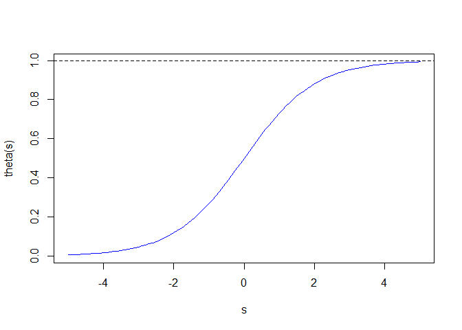

$\theta(s) = \frac{e^s}{1+ e^s} = \frac{1}{1+e^{-s}}$

- It’s smooth, monotonic sigmoid function of $s$
- logistic regression: use the following to approximate target function $f(x) = P(y|x)$

$h(x) = \frac{1}{1+ exp(-w^T x)}$

## Logistic Regression Error

**Three Linear Models**

- Linear Classification
  - $h(x) = \text{sign}(s)$
  - plausible err = 0/1 (small flipping noise)
- Linear Regression
  - $h(x) = s$
  - friendly err = squared (easy to minimize)
- Logistic Regression
  - $h(x) = \theta(s)$
  - err = ?

**Likelihood**

$f(x) = P(+1|x) \iff P(y|x) = \begin{cases} f(x) & \quad \text{for } y = +1 \\ 1-f(x) & \quad \text{for } y = -1 \\ \end{cases}$

- Consider $\mathcal{D} = {(x_1, \circ), (x_2, \times), \dots, (x_N, \times)}$
- probability that $f$ generates $\mathcal{D}$ is

$P(x_1)P(\circ | x_1) \times P(x_2)P(\times | x_2) \times \dots \times P(x_N)P(\times | x_N)$

- replace the above equation with $f(x)$

$P(x_1) \times f(x_1) P(x_2) (1 - f(x_2)) \times \dots \times P(x_N) (1 - f(x_N))$

- Likelihood that $h$ generates $\mathcal{D}$ is

$P(x_1) \times h(x_1) P(x_2) (1 - h(x_2)) \times \dots \times P(x_N) (1 - h(x_N))$

- if $h \approx f$, then likelihood($h$) $\approx$ probability using $f$
- probability using $f$ usually large

**Likelihood of Logistic Hypothesis**

- likelihood($h$) $\approx$ probability using $f \approx$ large
- $g = \underset{h}{\text{argmax}} \text{likelihood}(h)$
- when logistic: $h(x) = \theta(w^Tx)$
  - $1-h(x) = h(-x)$

$\text{likelihood}(h) = P(x_1) h(+x_1) P(x_2) h(-x_2) \cdots P(x_N) h(-X_N)$

So we have

$\text{likelihood}(\text{logistic } h) \propto \prod_{n=1}^{N} h(y_n x_n)$

**Cross-Entropy Error**

$\underset{w}{\text{max}}\ \text{likelihood } (w) \propto \prod_{n=1}^{N} \theta(y_n w^T x_n)$

$\underset{w}{\text{max}}\ \text{ln } \prod_{n=1}^{N} \theta(y_n w^T x_n)$

$\underset{w}{\text{min}}\ \frac{1}{N} \sum_{n=1}^{N} - \text{ln } \theta(y_n w^T x_n)$

$\underset{w}{\text{min}}\ \frac{1}{N} \sum_{n=1}^{N} \text{ln } (1 + exp(-y_n w^T x_n))$

$\underset{w}{\text{min}}\ \frac{1}{N} \underbrace{\sum_{n=1}^{N} \text{err}(w, x_n, y_n)}_{E_{in}(w)}$

- cross-entropy error: $\text{err}(w, x_n, y_n) = \text{ln } (1 + exp(-y_n w^T x_n))$

## Gradient of Logistic Regression Error

**Minimizing $E_{in}(w)$**

- $E_{in}(w)$: continuous, differentiable, twice-differentiable, **convex**
- how to minimize? locate valley, want $\nabla E_{in}(w) = 0$
- first: derive $\nabla E_{in}(w) = 0$

**The Gradient $\nabla E_{in}(w)$**

$E_{in}(w) = \frac{1}{N} \sum_{n=1}^{N} \text{ln } (1 + exp(-y_n w^T x_n))$

$\nabla E_{in}(w) = 1 / N \sum_{n=1}^{N} \theta(-y_n w^T x_n) (-y_n x_n)$

Note that in Andrew’s cource, the $\nabla E_{in}(w)$ is as following. Which is actually the same as above if we replace $y_n = 1$ and $y_n = -1$, and use $h(-x) = 1 - h(x)$ property. But *note*, in Andrew’s cource, $y_n$ can be 1 or 0, not $\pm 1$.

$\nabla E_{in}(w) = 1 / N \sum_{n=1}^{N} (h(x_n) - y_n) x_n$

**Minimizing $E_{in}(w)$**

$\nabla E_{in}(w) = 1 / N \sum_{n=1}^{N} \theta(-y_n w^T x_n) (-y_n x_n) = 0$

- scaled $\theta$-weighted sum of $-y_n x_n$
  - all $\theta(i) = 0$, only if $y_n w^T x_n \gg 0$ — Linear separable $\mathcal{D}$
  - weighted sum = 0: non-linear equation of $w$

**PLA revisited: iterative optimization**

PLA: start from some $w_0$, and correct its mistakes on $\mathcal{D}$

For $t = 0, 1, \dots$

1. find a mistake of $w_t$ called $(x_{n(t)}, y_{n(t)})$

$\text{sign}(w_t^Tx_{n(t)}) \ne y_{n(t)}$

2. try to correct the mistake by

$w_{t+1} \leftarrow w_t + y_{n(t)}x_{n(t)}$

when stop, return last $w$ as $g$

For $t = 0, 1, \dots$

1. (equivalently) pick some $n$, and update $w_t$ by

$w_{t+1} \leftarrow w_t + \underbrace{1}_{\eta} \cdot \underbrace{[\text{sign}(w_t^Tx_n) \ne y_n]y_{n(t)}x_{n(t)}}_{v}$

when stop, return last $w$ as $g$

- $v$ is the updates direction
- $\eta$ how big is the step in the direction
- choice of $(\eta, v)$ and stopping condition defines *iterative optimization approach*

## Gradient Descent

**Iterative Optimization**

For $t = 0, 1, \dots$

$w_{t+1} \leftarrow w_t + \eta v$

when stop, return last $w$ as $g$

- PLA: $v$ comes from mistake correction
- smooth $E_{in}(w)$ for logistic regression: choose $v$ to get the ball roll ‘downhill’
  - direction $v$: (assumed) of unit length
- a greedy approach for some given $\eta > 0$:

$\underset{|v| = 1}{\text{min}} E_{in} (\underbrace{w_t + \eta v}_{w_{t+1}})$

**Linear Approximation**

- still non-linear optimization, now with constraints
  - not any easier than $\text{min}_w E_{in} (w)$
- local approximation by linear formula makes problem easier.

$E_{in} (w_t + \eta v) \approx E_{in}(w_t) + \eta v^T \nabla E_{in}(w_t)$

- if $\eta$ really small (Taylor expansion)

an approximate greedy approach for some given small $\eta$:

$\underset{|v| = 1}{\text{min}} E_{in} (w_t) + \eta v^T \nabla E_{in}(w_t)$

**Gradient Descent**

- optimal $v$:

$v = - \frac{\nabla E_{in}(w_t)}{|\nabla E_{in}(w_t)|}$

- gradient descent: for small $\eta$

$w_{t+1} \leftarrow w_t - \eta \frac{\nabla E_{in}(w_t)}{|\nabla E_{in}(w_t)|}$

- a simple and popular optimization

**Choice of $\eta$**

- too small: too slow
- too large: too unstable
- just right: use changing $\eta$

$\eta$ better be monotonic of $\begin{Vmatrix}\nabla E_{in}(w_t)\end{Vmatrix}$

**Simple heuristic for changing $\eta$**

$w_{t+1} \leftarrow w_t - \eta \nabla E_{in}(w_t)$

- called the fixed learning rate

**Putting Everything Together**

Initialize $w_0$

For $t = 0, 1, \dots$

1. compute

$\nabla E_{in}(w_t) = 1 / N \sum_{n=1}^{N} \theta(-y_n w_t^T x_n) (-y_n x_n)$

2. update by

$w_{t+1} \leftarrow w_t - \eta \nabla E_{in}(w_t)$

… until $\nabla E_{in}(w_t) \approx 0$ or for enough iterations.

- Similer time complexity to pocket per iteration

## Conclusions

- Logistic Regression Problem
  - $P(+1|x)$ as target and $\theta(w^Tx)$ as hypothesis
- Logistic Regression Error
  - cross-entropy (negative log likelihood)
- Gradient of Logistic Regression Error
  - $\theta$-weighted sum of data vectors
- Gradient Descent
  - roll downhill by $-\nabla E_{in}(w_t)$

# Lecture 11 Linear Models for Classification

## Linear Models for Binary Classification

**Linear Models Revisited**

linear scoring function: $s = w^Tx$

- Linear Classification
  - $h(x) = \text{sign}(s)$
  - plausible err = 0/1 (discrete $E_{in}(w)$ NP hard to solve)
- Linear Regression
  - $h(x) = s$
  - friendly err = squared (quadratic convex $E_{in}(w)$: closed form solution)
- Logistic Regression
  - $h(x) = \theta(s)$
  - plausible err = cross-entropy (smooth convex $E_{in}(w)$: gradient descent)

Can linear regression or logistic regression help linear classfication? * linear classfication is hard to solve, but the other two are easy to solve * Can we use the other two to replace the first one?

**Error Functions Revisited**

linear scoring function: $s = w^Tx$

for binary classfication $\mathcal{y} \in {-1, +1}$

- Linear Classification
  - $h(x) = \text{sign}(s)$
  - err$(h, x, y) = [h(x) \ne y]$
  - $\text{err}_{0/1}(s, y) = [\text{sign}(s) \ne y] = [\text{sign}(ys) \ne 1]$
- Linear Regression
  - $h(x) = s$
  - err$(h, x, y) = (h(x) - y)^2$
  - $\text{err}_{SQR}(s, y) = (s - y)^2 = (ys-1)^2$
- Logistic Regression
  - $h(x) = \theta(s)$
  - err$(h, x, y) = \text{ln } h(yx)$
  - $\text{err}_{CE}(s, y) = \text{ln} (1+exp(-ys))$
- $(ys)$: classfication correctness score

**Visualizing Error Functions**

- $0/1$: 1 if and only if $ys \leq 0$
- sqr: large if $ys \ll 1$, but over-charge $ys \gg 1$, small $\text{err}_{SQR} \rightarrow \text{small } \text{err}_{0/1}$
- ce: monotonic of $ys$ small err CE $\iff$ small error 0/1.
- scaled ce: a proper upper bound of 0/1 small CE $\iff$ small error 0/1.
- upper bound: useful for designing Algorithmic error $\widehat{err}$

**Theoretical Implication of Upper Bound**

- For any $ys$ where $s = W^T x$

$\begin{split} \text{err}_{0/1}(s, y) \leq \text{err}_{SCE}(s, y) = \frac{1}{ln2} \text{err}_{CE}(s, y) \\ \iff \\ E_{in}^{0/1}(w) \leq E_{in}^{SCE}(w) = \frac{1}{ln2} E_{in}^{CE}(w) \\ E_{out}^{0/1}(w) \leq E_{out}^{SCE}(w) = \frac{1}{ln2} E_{out}^{CE}(w) \\ \end{split}$

- VC on 0/1

$E_{out}^{0/1}(w) \leq E_{in}^{0/1}(w) + \Omega^{0/1} \leq \frac{1}{ln2} E_{in}^{CE}(w) + \Omega^{0/1}$

- VC on CE:

$E_{out}^{0/1}(w) \leq \frac{1}{ln2} E_{out}^{CE}(w) \leq \frac{1}{ln2} E_{in}^{CE}(w) + \Omega^{0/1}$

- Either way, we have

$\text{small } E_{in}^{CE}(w) \Rightarrow \text{small } E_{out}^{0/1}(w)$

- logistic/linear reg. for linear classification.

**Regression for Classification**

1. run logistic/linear reg. on $\mathcal{D}$ with $y_n \in {-1, +1}$ to get $w_{reg}$
2. return $g(x) = \text{sign}(w_{reg}^T x)$
- linear regression
  - pros: ‘easiest’ optimization
  - cons: loose bound of err 0/1 for large $|ys|$
- logistic regression
  - pros: ‘easy’ optimization
  - cons: loose bound of err 0/1 for very negative $-ys$
- PLA
  - pros: efficient + strong guarantee if linear separable
  - cons: works only if linear separable, otherwise needing pocket heuristic
- linear regression sometimes used to set $w_0$ for PLA/pocket/logistic regression.
- logistic regression often preferred over pocket.

## Stochastic Gradient Descent

**Two Iterative Optimization Schemes**

For $t = 0, 1, \dots$

$w_{t+1} \leftarrow w_t + \eta v$

when stop, return last $w$ as $g$

- PLA: pick $(x_n, y_n)$ and decide $w_{t+1}$ by one example
  - $O(1)$ time per iteration.
- Logistic regression (pocket)
  - check $\mathcal{D}$ and decide $w_{t+1}$ by all examples
  - $O(N)$ time per iteration.

Is it possible to make logistic regression $O(1)$?

**Logistic Regression Revisited**

$w_{t+1} \leftarrow w_t + \eta \frac{1}{N} \sum_{n=1}^{N} \underbrace{\theta(-y_n w_t^{T} x_n) (y_n x_n)}_{- \nabla E_{in}(w_t)}$

- want: update direction $v \approx - \nabla E_{in}(w_t)$ while computing $v$ by one single $(x_n, y_n)$
- technique on removing $\frac{1}{N} \sum_{n=1}^{N}:$
  - view as expectation $\mathcal{E}$ over uniform choice of $n$!
  - Stochastic gradient: $\nabla_w \text{err}(w, x_n, y_n)$ with random $n$
  - true gradient: $\nabla_w E_{in}(w) = \underset{\text{random } n}{\mathcal{E}} \text{err}(w, x_n, y_n)$

**Stochastic Gradient Descent (SGD)**

Stochastic gradient = true gradient + zero-mean ‘noise’ directions

- idea: replace true gradient by stochastic gradient
- after enough steps, average true gradient $\approx$ average stochastic gradient
- pros: simple and cheaper computation
  - useful for big data and online learning
- cons: less stable in nature.

SGD logistic regression looks familiar?

$w_{t+1} \leftarrow w_t + \eta \underbrace{\theta(-y_n w_t^{T} x_n) (y_n x_n)}_{- \nabla \text{err}(w, x_n, y_n)}$

**PLA Revisited**

SGD logistic regression:

$w_{t+1} \leftarrow w_t + \eta \dot \theta (-y_n w_t^{T} x_n) (y_n x_n)$

PLA:

$w_{t+1} \leftarrow w_t + 1 \dot [y_n \ne \text{sign}(w_t^T x_n)] (y_n x_n)$

- SGD logistic regression $\approx$ ‘soft’ PLA
  - more errors, updates more. less errors ,updates less
- PLA $\approx$ SGD logistic regression with $\eta = 1$ when $w_t^T x_n$ large.

Two practical rule of thumb:

- stop condition? $t$ large enough
- $\eta$? 0.1 when $x$ in proper range

## Multiclass via Logistic Regression

**Multiclass Classification**

- $\mathcal{y} = {\star, \diamond, \circ, \times}$ 4-class classfication.
- many applications in practice, especially for ‘recognition’.
- Use tool for ${\times, \circ}$ for ${\star, \diamond, \circ, \times}$

**One Class at a time**

- $\square$ or not? ${\square = \circ, \diamond = \triangle = \star = \times}$
- $\diamond$ or not? ${\diamond = \circ, \square = \triangle = \star = \times}$
- $\triangle$ or not? ${\triangle = \circ, \square = \diamond = \star = \times}$
- $\star$ or not? ${\star = \circ, \square = \triangle = \diamond = \times}$

**Multiclass Prediction: Combine Binary Classifiers**

- We are sure some area is definitely what shape
- What about tie?

**One Class at a time softly**

- $P(\square|x)? \quad \{\square = \circ, \diamond = \triangle = \star = \times\}$
- $P(\diamond|x)? \quad \{\diamond = \circ, \square = \triangle = \star = \times\}$
- $P(\triangle|x)? \quad \{\triangle = \circ, \square = \diamond = \star = \times\}$
- $P(\star|x)? \quad \{\star = \circ, \square = \triangle = \diamond = \times\}$

**Multiclass Prediction: Combine Binary Classifiers**

$g(x) = \text{argmax}_{k \in \mathcal{Y}} \theta(w_{[k]}^Tx)$

OR, equivalently

$g(x) = \text{argmax}_{k \in \mathcal{Y}} w_{[k]}^Tx$

**One-Versus-All (OVA) Decomposition**

1. for $k \in \mathcal{Y}$, obtain $w_{[k]}$ by running logistic regression on
   - $\mathcal{D}_{[k]} = \{(x_n, y_n = 2[y_n = k] - 1)\}_{n=1}^N$
2. return $g(x) = \text{argmax}_{k \in \mathcal{Y}} (w_{[k]}^T x)$
- pros: efficient, can be coupled with any logistic regression-like approaches.
- cons: often unbalanced $\mathcal{D}_{[k]}$ when $K$ large
  - logistic regression will produce naive predictor: predict everything to be $\times$.
- extension: multinomial (‘coupled’) logistic regression.

OVA: a simple Multiclass meta-algorithm to keep in your toolbox.

## Multiclass via Binary Classification

**Source of Unbalance: One Versus All**

idea: make binary classification problems more balanced by one versus one.

**One versus One at a Time**

- $\square or \diamond$ ? {$\square = \circ, \diamond = \times, \star = \triangle = \text{nil}$}
- …

**Multiclass Prediction: Combine Pairwise Classifiers**

$g(x) = \text{tournament champion } \{w_{[k, l]}^T x\}$

voting of classifiers.

**One-versus-one OVO Decomposition**

1. for $[k, l] \in \mathcal{Y} \times \mathcal{Y}$, obtain $w_{[k, l]}$ by running logistic regression on
   - $\mathcal{D}_{[k, l]} = \{(x_n, y'_n = 2[y_n = k] - 1): y_n = k \text{or } y_n = l\}$
2. return $g(x) = \text{tournament champion } \{w_{[k, l]}^T x\}$
- pros: efficient (‘smaller’ Training problems), stable, can be coupled with any binary classification approaches.
- cons: use $O(K^2)w_{[k, l]}$
  - more space, slower prediction, more training.

OVO: another simple Multiclass meta-algorithm to keep in your toolbox.

- Very handy and stable!

## Conclusions

- Linear Models for Binary Classification
  - three models useful in different ways
- Stochastic Gradient Descent
  - follow negative stochastic gradient
- Multiclass via Logistic Regression
  - predict with maximum estimated P(k|x)
- Multiclass via Binary Classification
  - predict the tournament champion

# Lecture 12 Nonlinear Transformation

## Quadratic Hypothesis

**Linear Hypothesis**

- visually: ‘line’-like boundary
- mathematically: linear scores $s = w^T x$

limitations:

- theoretically: $d_{vc}$ under control
- practically: on some $\mathcal{D}$, large $E_{in}$ for every line.

How to break the limit of linear hypothesis?

**Circular Separable**

- $\mathcal{D}$ not linear separable
- but circular separable by a circle of radius $\sqrt{0.6}$ centered at origin:

$h_{SEP}(x) = \text{sign } (-x_1^2 - x_2^2 + 0.6)$

re-derive Circular-PLA, Circular-Regression, blahblah … all over again?

**Circular Separable and Linear Separable**

$h(x) = \text{sign } ( \underbrace{0.6}_{\tilde{w_0}} \cdot \underbrace{1}_{\tilde{z_0}} + \underbrace{(-1)}_{\tilde{w_1}} \cdot \underbrace{x_1^2}_{\tilde{z_1}} + \underbrace{(-1)}_{\tilde{w_2}} \cdot \underbrace{x_2^2}_{\tilde{z_2}} ) = \text{sign } ( \tilde{w}^T z )$

- $\{(x_n, y_n)\}$ cicular separable $\implies \{(x_n, y_n)\}$ linear separable.
- $x \in \mathcal{X} \overset{\Phi}{\mapsto} z \in \mathcal{Z}$: nonlinear feature transform $\Phi$.
- circular separable in $\mathcal{X} \mapsto$ linear separable in $\mathcal{Z}$
- What about vice versa?

**Linear Hypothesis in Z space**

$(z_0, z_1, z_2) = z = \Phi(x) = (1, x_1^2, x_2^2)$

$h(x) = \tilde{h}(z) = \text{sign}(\tilde{w}^T \Phi(x)) = \text{sign} (\tilde{w_0} + \tilde{w_1}x_1^2 + \tilde{w_2}x_2^2)$

$(\tilde{w_0}, \tilde{w_1}, \tilde{w_2})$

- $(0.6, -1, -1)$: circle ($\circ$ inside)
- $(-0.6, +1, +1)$: circle ($\circ$ outside)
- $(0.6, -1, -2)$: ellipse
- $(0.6, -1, +2)$: hyperbola
- $(0.6, +1, +2)$: constant $\circ$

line in $\mathcal{Z} \iff$ special quadratic curves in $\mathcal{X}$ space.

- E.g., the center of a circle must be the origin

**General Quadratic Hypothesis set**

a bigger $\mathcal{Z}$ with $\Phi_2(x) = (1, x_1, x_2, x_1^2, x_1x_2, x_2^2)$

Perceptrons in $\mathcal{Z}$ space $\iff$ quadratic hypothesis in $\mathcal{X}$ space

$\mathcal{H}(\Phi_2) = {h(x): h(x) = \tilde{h}(\Phi_2(x)) \text{for some linear } \tilde{h} on \mathcal{Z}}$

- Can implement all possible quadratic curve boundries: circle, ellipse, rotated ellipse, hyperbola, parabola

$\text{ellipse } 2 (x_1 + x_2 - 3)^2 + (x_1 - x_2 - 4)^2 = 1$

$\implies \tilde{w}^T = (33, -20, -4, 3, 2, 3)$

- Include lines and constants as degenerated cases
- next: learn a good quadratic hypothesis $g$

## Nonlinear Transform

**Good Quadratic Hypothesis**

- $\mathcal{Z}$ space perceptrons $\iff$ $\mathcal{X}$ quadratic hypothesis
- good perceptron $\iff$ good quadratic hypothesis
- separating perceptron $\iff$ separating quadratic hypothesis
- want: good perceptron in $\mathcal{Z}$ space
- know: get good perceptron in $\mathcal{X}$ space with data $(x_n, y_n)$
- todo: get good perceptron in $\mathcal{Z}$ space with data $(z_n = \Phi_2(x_n), y_n)$

**Nonlinear Transform Steps**

- transform original data $(x_n, y_n)$ to $(z_n = \Phi_2(x_n), y_n)$ by $\Phi$
- Get a good perceptron $\tilde{w}$ using $(z_n, y_n)$ and your favorite linear classification algorithm $\mathcal{A}$
- return $g(x) = \text{sign}(\tilde{w}^T \Phi(x))$

**Nonlinear Model via Nonlinear $\Phi$ + Linear Models**

- Two choices: feature transform $\Phi$
- Linear model $\mathcal{A}$, not just binary classification
- Pandora’s box: can now freely do quadratic PLA, quadratic regression, cubic, …, polynomial regression.

**Feature Transform**

- not new, not just polynomial:
- In digits recognition:
  - raw (pixels) $\overset{\text{domain knowledge}}{\implies}$ concrete (intensity, symmetry)
- the force: too good to be true?

## Price of Nonlinear Transform

**Computation/Storage Price**

$Q$-th order polynomial transform:

$\begin{split} ( 1, \\ x_1, x_2, \dots, x_d, \\ x_1^2, x_1x_2, \dots, x_d^2, \\ \dots, \\ x_1^Q, x_1^{Q-1}x_2, \dots, x_d^Q) \end{split}$

- $\underbrace{1}_{\tilde{w_0}} + \underbrace{\tilde{d}}_{\text{others}}$ dimensions = # ways of $\leq Q$-combination for $d$ kinds with repetitions
- = $\binom{Q+d}{Q} = \binom{Q+d}{d} = O(Q^d)$
- = efforts needed for computing/storing $z = \Phi_{Q}(x)$ and $\tilde{x}$
- $Q$ large $\implies$ difficult to compute/store

**Model Complexity Price**

- $\underbrace{1}_{\tilde{w_0}} + \underbrace{\tilde{d}}_{\text{others}}$ dimensions = $O(Q^d)$
- number of free parameters $\tilde{w_i} = \tilde{d} + 1 \approx d_{VC}(\mathcal{H}_{\Phi_Q})$
- $d_{VC}(\mathcal{H_{\Phi_{Q}}}) \leq \tilde{d} + 1$, why?
  - any $\tilde{d} + 2$ inputs not shattered in $\mathcal{Z}$
  - $\implies$ any $\tilde{d} + 2$ inputs not shattered in $\mathcal{X}$
- $Q$ large $\implies$ large $d_{VC}$

**Generalization Issue**

- Which do you prefer?
  - $\Phi_1$ (original $x$), visually preferable.
  - $\Phi_4$, $E_{in}(g) = 0$ but overkill.
1. Can we make sure that $E_{in}(g)$ is close enough to $E_{out}(g)$?
2. Can we make $E_{in}(g)$ small enough?
- Higher $\tilde{d}(Q)$, good for 2, bad for 1
- Lower $\tilde{d}(Q)$, good for 1, bad for 2
- how to pick $Q$. visually, maybe?

**Danger of Visual Choices**

- First of all, can you really ‘visualize’ when $\mathcal{X} = \mathbb{R}^10$?

Visualize $\mathcal{X} = \mathbb{R}^2$

- For VC-safety, $\Phi$ shall be decided without ‘peeking’ data.

## Structured Hypothesis Sets

**Polynomial Transform Revisited**

$\begin{split} \Phi_0(x) = 1 \\ \Phi_1(x) = (\Phi_0(x), \quad x_1, x_2, \dots, x_d) \\ \Phi_2(x) = (\Phi_1(x), x_1^2, x_1x_2, \dots, x_d^2) \\ \dots \dots \\ \Phi_Q(x) = (\Phi_{Q-1}(x), x_1^Q, x_1^{Q-1}, \dots, x_d^Q) \end{split}$

$\mathcal{H}_{\Phi_0} \subset \mathcal{H}_{\Phi_1} \subset \mathcal{H}_{\Phi_2} \subset \cdots \subset \mathcal{H}_{\Phi_Q}$

**Structured Hypothesis Sets**

$\mathcal{H}_0 \subset \mathcal{H}_1 \subset \mathcal{H}_2 \subset$

$d_{VC}(\mathcal{H}_0) \leq d_{VC}(\mathcal{H}_1) \subset d_{VC}(\mathcal{H}_2) \leq \cdots$

- Use a high dimension from beginning is not a good idea.

**Linear Model First**

- tempting sin: use $\mathcal{H}_{1126}$, low $E_{in}(g_{1126})$ to fool your boss.
  - really? :( a dangerous path of no return
- safe route: $\mathcal{H}_1$ first
  - if $E_{in}(g_1)$ good enough, live happily thereafter :)
  - otherwise, move right of the curve with nothing lost except ‘wasted’ computation.
- linear model first: simple, efficient, safe and workable.

## Conclusions

- Quadratic Hypothesis
  - linear hypothesis on quadratic-transformed data
- Nonlinear Transform
  - happy linear modeling after $\mathcal{Z} = \Phi(\mathcal{X})$
- Price of Nonlinear Transform
  - computation/storage/model complexity
- Structured Hypothesis Sets
  - linear/simple model first

# Lecture 13 Hazard of Overfitting

nonlinear (regression, classification) via nonlinear feature transform $\Phi$ plus linear (regression, classification) with price of model complexity. However, it will causes overfitting. In this lecture:

- How does it happen?
- How to overcome it?

## What is overfitting?

**Bad Generalization**

- regression for $x \in \mathbb{R}$ with $N = 5$ examples
- target $f(x) = $ 2nd order polynomial
- label $y_n = f(x_n) +$ very small noise
- linear regression in $\mathcal{Z}$-space + $\Phi$ = 4th order polynomial
- unique solution passing all examples $\implies E_{in}(g) = 0$
- $E_{out}(g)$ huge

bad generalization: low $E_{in}$, high $E_{out}$.

**Bad Generalization and Overfitting**

bad generalization: low $E_{in}$, high $E_{out}$. overfitting: lower $E_{in}$, higher $E_{out}$

**Cause of Overfitting: A Driving Analogy**

‘good fit’ $\implies$ ‘overfit’

| Learning | Driving |
| --- | --- |
| overfit | commit a car accident |
| use excessive $d_{VC}$ | ‘drive too fast’ |
| noise | bumpy road |
| limited data size $N$ | limited observations about road condition |

next: how does noise & data size affect overfitting?

## The role of Noise and Data size

**Case Study**

10-th order target function + noise 50-th order target function + noiseless

overfitting from best $g_2 \in \mathcal{H}_2$ to best $g_{10} \in \mathcal{H}_{10}$ ?

10-th order target function + noise

$\begin{array}{c|c c} & g_2 \in \mathcal{H}_2 & g_{10} \in \mathcal{H}_{10} \\ \hline E_{in} & 0.050 & 0.034 \\ E_{out} & 0.127 & 9.0 \end{array}$

50-th order target function + noiseless

$\begin{array}{c|c c} & g_2 \in \mathcal{H}_2 & g_{10} \in \mathcal{H}_{10} \\ \hline E_{in} & 0.029 & 0.00001 \\ E_{out} & 0.120 & 7680 \end{array}$

**Irony of Two learners**

- Learner $O$verfit: pick $g_{10} \in \mathcal{H}_{10}$
- Learner $R$estricted: pick $g_{2} \in \mathcal{H}_{2}$
- When both know that target = 10th
  - R ‘give up’ ability to fit

But $R$ wins in $E_{out}$ a lot. Philosophy: concession for advantages? 以退为进！

**Learning Curves Revisited**

**No Noise Case**

- Learner $O$verfit: pick $g_{10} \in \mathcal{H}_{10}$
- Learner $R$estricted: pick $g_{2} \in \mathcal{H}_{2}$
- When both know that there is no noise
  - $R$ still wins

Is there really no noise? ‘Target complexity’ acts like noise.

## Deterministic Noise

**A Detailed Experiment**

$y = f(x) + \epsilon \sim \text{Gaussian} (\sum_{q=0}^{Q_f} \alpha_{q} x^q, \sigma^2)$

- Gaussian iid noise $\epsilon$ with noise $\sigma^2$.
- Some ‘uniform’ distribution on $f(x)$ with complexity level $Q_{f}$
- data size $N$

**The Overfit Measure**

- $g_{2} \in \mathcal{H}_{2}$
- $g_{10} \in \mathcal{H}_{10}$
- $E_{in}(g_{10}) \leq E_{in}(g_{2})$ for sure.

Overfit measure $E_{out}(g_{10}) - E_{out}(g_{2})$

**The Results**

- impact of $\sigma^2$ versus $N$
  - Less noise (small ), more data points $N$, less overfit.
- impact of $Q_{f}$ versus $N$
  - Less complex of objective function (smaller $Q_{f}$), more data points $N$, less overfit.
- The logo of this class
  - Middle two figures: overfit
  - left: nonlinear transformation
  - right: linear learning

**Impact of Noise and Data Size**

- impact of $\sigma^2$ versus $N$: stochastic noise
- impact of $Q_{f}$ versus $N$: deterministic noise
- four reasons of serious overfitting:
  - data size $N \downarrow$
  - stochastic noise $\uparrow$
  - deterministic noise $\uparrow$
  - excessive power $\uparrow$, VC dimension is too high

overfitting ‘easily’ happens.

**Deterministic Noise**

- if $f \notin \mathcal{H}$: something of $f$ cannot be captured by $\mathcal{H}$
- deterministic noise: difference between best $h^* \in \mathcal{H}$ and $f$
- acts like stochastic noise: not new, pseudo-random generator
- difference to stochastic noise:
  - depends on $\mathcal{H}$
  - fixed for a given x

Philosophy: when teaching a kid, perhaps better not to use examples from a complicated target function? :)

## Dealing with Overfitting

**Driving Analogy Revisited**

| Learning | Driving |
| --- | --- |
| overfit | commit a car accident |
| use excessive $d_{VC}$ | ‘drive too fast’ |
| noise | bumpy road |
| limited data size $N$ | limited observations about road condition |

| Learning | Driving |
| --- | --- |
| start from simple model | drive slowly |
| data cleaning/pruning | use more accurate road information |
| data hint | exploit more road information |
| regularization | put the breaks |
| validation | monitor the dashboard |

All very practical techniques to combat overfitting.

**Data Cleaning/Pruning**

- if ‘detects’ the outlier 5 at the top by
  - too close to other $\circ$, or too far from other $\times$
  - wrong by current classifer
  - …
- possible action 1: correct the label (data cleaning)
- possible action 2: remove the example (data pruning)

Possibly helps: but effect varies

**Data Hinting**

- slightly shifted/rotated digits carry the same meaning
- possible action: add virtual examples by shifting/rotating the given digits (data hinting)

Possibly helps: but watch out - virtual example not $\overset{iid}{\sim} P(x, y)$!

## Conclusions

- What is overfitting?
  - lower $E_{in}$, but higher $E_{out}$
- The role of Noise and Data size
  - overfitting ‘easily’ happens
- Deterministic Noise
  - what $\mathcal{H}$ cannot capture acts like noise
- Dealing with Overfitting
  - data cleaning/pruning/hinting, and more

# Lecture 14 Regularization (规则化/规律化)

Overfitting happens with excessive power, stochastic/deterministic noise, and limited data.

## Regularized Hypothesis set

**Regularization: The Magic**

overfit $\implies$ ‘regularized fit’

- idea: ‘step back’ from $\mathcal{H}_{10}$ to $\mathcal{H}_{2}$
- name history: function approximation for ill-posed problems

how to step back?

**Stepping Back as Constraint**

$Q$-th order polynomial transform for $x \in \mathbb{R}$:

$\Phi_{Q}(x) = (1, x, x^2, \dots, x^Q)$

+linear regression, denote $\tilde{w}$ by w

- hypothesis w in $\mathcal{H}_{10}$: $w_0 + w_1 x + w_2 x^2 + \dots + w_{10} x^{10}$
- hypothesis w in $\mathcal{H}_{2}$: $w_0 + w_1 x + w_2 x^2$
- that is, $\mathcal{H}_{2} = \mathcal{H}_{10}$ AND ‘Constraint that $w_3 = \dots = w_{10} = 0$’
- step back = ‘constraints’

**Regression with Constraint**

- $\mathcal{H}_{10} \equiv {w \in \mathbb{R}^{10+1}}$
  - regression with $\mathcal{H}_{10}$: $\underset{w\in\mathbb{R}^{10+1}}{\text{min}} E_{in}(w)$
- $\mathcal{H}_{2} \equiv {w \in \mathbb{R}^{10+1} \text{while} w_3 = \dots = w_{10} = 0}$
  - regression with $\mathcal{H}_{2}$:
  - $\underset{w\in\mathbb{R}^{10+1}}{\text{min}} E_{in}(w)$
  - $s.t. w_3 = \dots = w_{10} = 0$

step back = constrained optimization of $E_{in}$

Why don’t you just use $w in \mathbb{R}^{2+1}$

**Regression with Looser Constraint**

- $\mathcal{H}_{2} \equiv {w \in \mathbb{R}^{10+1} \text{while} w_3 = \dots = w_{10} = 0}$
  - regression with $\mathcal{H}_{2}$:
  - $\underset{w\in\mathbb{R}^{10+1}}{\text{min}} E_{in}(w)$
  - $s.t. w_3 = \dots = w_{10} = 0$

Relax to:

- $\mathcal{H'}_{2} \equiv {w \in \mathbb{R}^{10+1} \text{while} \ge 8 \text{of } w_{q}= 0}$
  - regression with $\mathcal{H'}_{2}$:
  - $\underset{w\in\mathbb{R}^{10+1}}{\text{min}} E_{in}(w)$
  - $\text{s.t.} \sum_{q=0}^{10} [w_q \ne 0] \le 3$
- more flexible than $\mathcal{H}_2$: $\mathcal{H}_{2} \in \mathcal{H'}_{2}$
- less risky than $\mathcal{H}_10$: $\mathcal{H'}_{2} \in \mathcal{H'}_{10}$

Bad news for sparse hypothesis set $\mathcal{H'}_{2}$: NP-hard to solve.

- Boolean operation, discrete.

**Regression with Softer Constraint**

Relax to:

$\begin{split} \mathcal{H}(C) \equiv { w \in \mathbb{R}^{10+1} \text{while} |w|^2 \le C } \\ \underset{w\in\mathbb{R}^{10+1}}{\text{min}} E_{in}(w) \text{s.t. } \sum_{q=0}^{10} w_q^2 \le C \end{split}$

- $\mathcal{H}(C)$: overlaps but not exactly the same as $\mathcal{H'}_2$
- soft and smooth Structure over $C \ge 0$:
  - $\mathcal{H}(0) \in \mathcal{H}(1.126) \in \dots \in \mathcal{H}(1126) \in \dots \in \mathcal{H}(\infty) = \mathcal{H}_{10}$

regularized hypothesis $w_{REG}$: optimal solution from regularized hypothesis set $\mathcal{H}(C)$

## Weighted Decay Regularization

**Matrix Form of Regularized Regression Problem**

$\begin{split} \underset{w\in\mathbb{R}^{Q+1}}{\text{min}} E_{in}(w) = \frac{1}{N} \sum_{n=1}^{N} (w^T z_n - y_n)^2 \\ \text{s.t. } \sum_{q=0}^{Q} w_q^2 \le C \end{split}$

- $\sum_n = (Zw - y)^T(Zw - y)$
- $w^Tw \le C$: feasible $w$ within a radius-$\sqrt(C)$ hypersphere

How to solve the constrained optimization problem?

**The Lagrange Multiplier**

$\underset{w\in\mathbb{R}^{Q+1}}{\text{min}} E_{in}(w) = \frac{1}{N} (Zw - y)^T(Zw - y) \text{s.t. } w^Tw \le C$

**Augmented Error**

- if oracle tells you $\lambda > 0$, then solving $\nabla E_{in}(w_{REG}) + \frac{2 \lambda}{N} w_{REG} = 0$

$\frac{2}{N}(Z^T Z w_{REG} - Z^T y) + \frac{2 \lambda}{N} w_{REG} = 0$

- optimal solution:

$w_{REG} \leftarrow (Z^T Z + \lambda I)^{-1} Z^T y$

- $(Z^T Z + \lambda I)$ always invertible.
- called ridge regression in Statistics.

Another view, equivalent to minimizing augmented error $E_{aug}(w)$:

$E_{in}(w) + \frac{\lambda}{N} w^{T} w$

- regularization with augmented error instead of constrained $E_{in}$

$w_{REG} \leftarrow \underset{w}{\text{argmin}} E_{aug}(w) \text{for given} \lambda \text{ or } \lambda = 0$

- minimizing unconstrained $E_{aug}$ effectively minimizes some $C$-constrained $E_{in}$

**The Results**

- $\lambda = 0$, overfitting
- $\lambda = 0.0001$, OK
- $\lambda = 0.01$, OK
- $\lambda = 1$, underfitting, complexity is not enough.
- Philosophy: a little **regularization** goes a long way.

call ‘$+\frac{\lambda}{N} w^T w$’ weight-decay regularization:

- larger $\iff$
- prefer shorter $w \iff$
- effectively smaller $C$

Go with any transform + linear model

**Some details: Legendre Polynomials**

$\underset{w\in\mathbb{R}^{Q+1}}{\text{min}} \frac{1}{N} \sum_{n=0}^{N} (w^T \Phi(x_n) - y_n^2)^2 + \frac{1}{N} \sum_{q=0}^{Q} w_q^2$

naive polynomial transform:

$\Phi(x) = (1, x, x^2, \dots, x^Q)$

When $x_n \in [-1, +1]$, $x_n^q$ really small, needing large $w_q$.

- We need large $w_Q$ for big $Q$. We penalize too much for the high dimension.

normalized polynomial transform:

$(1, L_1(x), L_2(x), \dots, L_Q(x))$

orthonormal basis functions called Legendre Polynomials

## Regularization and VC Theory

**Regularization and VC Theory**

- Regularization by constrained-minimizing $E_{in}$

$\underset{w}{\text{min}} E_{in}(w) \text{s.t. } w^T w \le C$

- Regularization by Minimizing $E_{aug}$

$\underset{w}{\text{min}} E_{aug}(w) = E_{in}(w) + \frac{\lambda}{N} w^Tw$

- VC Guarantee of constrained-minimizing $E_{in}$

$E_{out}(w) \le E_{in}(w) + \Omega(\mathcal{H}(C))$

minimizing $E_{aug}$: indirectly getting VC guarantee without confining to $\mathcal{H}(C)$.

**Another View of Augmented Error**

- Augmented Error: $E_{aug}(w) = E_{in}(w) + \frac{\lambda}{N} w^Tw$
- VC Bound: $E_{out}(w) \le E_{in}(w) + \Omega(\mathcal{H}(C))$
- regularizer $w^Tw = \Omega(w)$: complexity of a single hypothesis
- generalization price $\Omega(\mathcal{H})$: complexity of a hypothesis set
- if $\frac{\lambda}{N}\Omega(w)$ ‘represents’ $\Omega(\mathcal{H})$ well, $E_{aug}$ is a better proxy of $E_{out}$ than $E_{in}$
- minimizing $E_{aug}$:
  - (heuristically) operating with the better proxy;
  - (technically) enjoying the flexibility of whole $\mathcal{H}$

**Effective VC Dimenson**

$\underset{w\in\mathbb{R}^{\tilde{d}+1}}{\text{min}} = E_{in}(w) + \frac{\lambda}{N}\Omega(w)$

- model complexity?
  - $d_{VC}(\mathcal{H}) = \tilde{d} + 1$, because {$w$} ‘all considered’ during minimization
- {$w$} ‘actually needed’: $\mathcal{H}(C)$, with some $C$ equivalent to $\lambda$
- $d_{VC}(\mathcal{H}(C))$: effective VC dimension $d_{EFF}(\mathcal{H}, \underbrace{\mathcal{A}}_{\text{min} E_{aug}})$

explanation of regularization: $d_{VC}(\mathcal{H})$ large, while $d_{EFF}(\mathcal{H}, \mathcal{A})$ small if $\mathcal{A}$ regularized.

## General Regularizers

**General Regularizers $\Omega(w)$**

want: constraint in the ‘direction’ of target function

- target-dependent: some properties of target, if known (domain knowledge)
  - symmetry regularizer: $\sum$ [q is odd] $w_q^2$
- plausible: direction towards smoother or simple
  - regularization is to overcome noise
  - stochastic/deterministic noise both non-smooth
  - sparsity (L1) regularizer: $\sum |w_q|$
- friendly: easy to opmitize
  - weight-decay (L2) regularizer: $\sum w_q^2$
- bad? no worries, guard by $\lambda$
- augmented error = error $\widehat{\text{err}}$ + regularizer $\Omega$
- regularizer: target-dependent, plausible or friendly. ringing a bell?
- error measure: user-dependent, plausible or friendly.

**L2 and L1 Regularizer**

- L2 Regularizer
  - $\Omega(w) = \sum_{q=0}^{Q} w_q^2 = \begin{Vmatrix} w \end{Vmatrix}_2^2$
  - convex, differentiable everywhere
  - easy to optimize
- L1 Regularizer
  - $\Omega(w) = \sum_{q=0}^{Q} |w_q| = \begin{Vmatrix} w \end{Vmatrix}_1$
  - convex, not differentiable everywhere
  - sparsity in solution
  - optimal solution is often at the corner, meaning some $w$ is 0.

L1 useful if needing sparse solution.

**The Optimal $\lambda$**

- more noise $\iff$ more regularization needed
  - more bumpy road $\iff$ putting brakes more
- noise unknown - important to make proper choices

How to choose? Stay tuned for the next lecture!

## Conclusions

- Regularized Hypothesis set
  - original $\mathcal{H}$ + constraint
- Weighted Decay Regularization
  - add $\frac{\lambda}{N} w^Tw$ in $E_{aug}$
- Regularization and VC Theory
  - regularization decreases $d_{\text{EFF}}$
- General Regularizers
  - target-dependent, plausible or friendly.

# Lecture 15 Validation

minimizes augmented error, where the added regularizer effectively limits model complexity.

## Model Selection Problem

**So Many Models Learned**

Even just for Binary Classification …

- $\mathcal{A} \in$ {PLA, pocket, linear regression, logistic regression}
- $T \in$ {100, 1000, 10000}
- $\eta \in$ {1, 0.01, 0.0001}
- $\Phi \in$ {linear, quadratic, poly-10, Legendre-poly-10}
- $\Omega(w) \in$ {L2 regularizer, L1 regularizer, symmetry, regularizer}
- $\lambda \in$ {0, 0.01, 1}

in addition to your favorite combination, may need to try other combination to get a good $g$.

**Model Selection Problem**

- Which one do you prefer? Linear $\mathcal{H}_1$ or quadratic $\mathcal{H}_2$?
- given: $M$ models $\mathcal{H}_1, \mathcal{H}_2, \dots, \mathcal{H}_M$, each with corresponding algorithm $\mathcal{A}_1, \mathcal{A}_2, \dots, \mathcal{A}_M$
- goal: select $\mathcal{H}_{m*}$ such that $g_{m*} = \mathcal{A}_{m*}(\\mathcal{D})$ is of low $E_{out}(g_{m*})$
- unknown $E_{out}$ due to unknown $P(x)$ & $P(y|x)$, as always.
- arguably the most important practical problem of ML.

How to select? visually? No! See lecture 12.

- Not always can be visualized.
- The high VC dimension in the human brain.

**Model Selection by Best $E_{in}$**

- select by best $E_{in}$?
  - $m* = \underset{1 \le m \le M}{E_m = E_{in}(\mathcal{m}(\mathcal{D}))}$
- $\Phi_{1126}$ always more preferred over $\Phi_1$
- $\lambda = 0$ always more preferred over $\lambda = 0.1$ - overfitting
- if $\mathcal{A}_1$ minimizes over $\mathcal{H}_1$ and $\mathcal{A}_2$ minimizes over $\mathcal{H}_2$,
  - $\implies g_{m*}$ achieves minimal $E_{in}$ over $\mathcal{H}_{1} \cup \mathcal{H}_{2}$
  - $\implies$ Extra model complexity, learning pays $d_{VC}(\mathcal{H}_{1} \cup \mathcal{H}_{2})$
  - bad generalization?

selecting by $E_{in}$ is dangerous.

**Model Selection by Best $E_{test}$**

- select by best $E_{test}$, which is evaluated on a fresh $\mathcal{D}_{test}$?
  - $m* = \underset{1 \le m \le M}{E_m = E_{test}(\mathcal{m}(\mathcal{D}))}$
- generalization guarantee (finite-bin Hoeffding):
  - yes! strong guarantee! $E_{out}(g_{m*}) \le E_{test}(g_{m*}) + O(\sqrt{\frac{\text{log}M}{N_{\text{test}}}})$
- But where is $\mathcal{D}_{test}$? Your boss’s safe, maybe?

selecting by $E_{test}$ is infeasible and cheating!

**Comparison between $E_{in}$ and $E_{test}$**

- in-sample error $E_{in}$
  - calculate from $\mathcal{D}$
  - feasible on hand
  - ‘contaminated’ as $\mathcal{D}$ also used by $\mathcal{A}_{m}$ to select $g_{m}$
- test error $E_{test}$
  - calculate from $\mathcal{D}_{test}$
  - infeasible in boss’s safe
  - ‘clean’ as $\mathcal{D}_{test}$ never used for selection before
- something in between: $E_{val}$
  - calculate from $_{val} $\mathcal{D}$
  - feasible on hand
  - clean if $\mathcal{D}_{val}$ never used by $\mathcal{A}_{m}$ before.

selecting by $E_{val}$: legal cheating.

## Validation

**Validation Set $\mathcal{D}_{val}$**

$\underbrace{\mathcal{D}}_{\text{size } N} \leftarrow \underbrace{\mathcal{D}_{train}}_{\text{size } N-K} \cup \underbrace{\mathcal{D}_{val}}_{\text{size } K}$

- $\mathcal{D}_{val} \subset \mathcal{D}$: called validation set - ‘on hand’ simulation of test set to connect $E_{val}$ with $E_{out}$:
  - $\mathcal{D}_{val} \underset{iid}{\sim} P(x, y)$: select $K$ examples from $\mathcal{D}$ at random
- to make sure $\mathcal{D}_{val}$ ‘clean’: feed only $\mathcal{D}_{train}$ to $\mathcal{A}_m$ for model selection.
- $g_{m} = \mathcal{A}_m(\mathcal{D})$
- $g_{m}^- = \mathcal{A}_m(\mathcal{D}_{train})$

$E_{out}(g_m^-) \le E_{val}(g_m^-) + O(\sqrt{\frac{\\text{log} M}{K}})$

**Model Selection by Best $E_{val}$**

$m* = \underset{\text{argmin}}{1 \le m \le M} (E_{in} = E_{val}(\mathcal{A}_m(\mathcal{D}_{train})))$

- generalization guarantee for all $m$:
  - $E_{out}(g_m^-) \le E_{val}(g_m^-) + O(\sqrt{\frac{\\text{log} M}{K}})$
- heuristic gain from $N-K$ to $N$:
  - $E_{out}(\underbrace{g_{m*}}_{\mathcal{A}_{m*}(\mathcal{D})}) \le E_{out}(\underbrace{g_{m*}^-}_{\mathcal{A}_{m}(\mathcal{D}_{train})})$
  - This is because learning curve.
- The general flow:
1. divide $\mathcal{D}$ to $\mathcal{D}_{val}$ and $\mathcal{D}_{train}$.
2. Obtain $M$ models $g_1^- \dots g_M^-$
3. pick the best one $\{\mathcal{H}_{m*}, \mathcal{E}_{m*}\}$
4. use $\mathcal{D}$ to find $g_{m*}$ in $\mathcal{H}_{m*}$

$E_{out}(g_{m*}) \le E_{out}(g_{m*}^-) \le E_{val}(g_{m*}^-) + O(\sqrt{\frac{\\text{log} M}{K}})$

**Validation in Practice**

use validation to select between $\mathcal{H}_{\Phi_5}$ and $\mathcal{H}_{\Phi_{10}}$

- in-sample: selection with $E_{in}$
- optimal: cheating-selection with $E_{test}$
- sub-$g$: selection with $E_{val}$ and report $g_{m*}^-$
- full-$g$: selection with $E_{val}$ and report $g_{m*}$
  - $E_{out}(g_{m*}) \le E_{out}(g_{m*}^-)$ indeed.

Why is sub-$g$ worse than in-sample some time?

- $\mathcal{D}_{val} \uparrow$ and $\mathcal{D}_{train} \downarrow$.

**The Dilemma about $K$**

reasoning of validation:

$E_{out}(g) \underset{(\text{small } K)}{\approx} E_{out}(g^-) \underset{(\text{large } K)}{\approx} E_{val}(g^-)$

- large $K$: every $E_{val} \approx E_{out}$, but all $g_m^-$ much worse than $g_m$
- small $K$: every $g_m^- \approx g_m$, but $E_{val}$ far from $E_{out}$

Practical rule of thumb: $K = \frac{N}{5}$

**Fun Time**

Validation might not be slow! Because we use less $\mathcal{D}_{train}$.

## Leave-One-Out Cross Validation

**Extreme Case: $K = 1$**

reasoning of validation:

$E_{out}(g) \underset{(\text{small } K)}{\approx} E_{out}(g^-) \underset{(\text{large } K)}{\approx} E_{val}(g^-)$

- take $K = 1$? $\mathcal{D}_{val}^{(n)} = \{(x_n, y_n\}$ and $E_{val}^{(n)}(g_n^-) = \text{err}(g_{n}^-(x_n), y_n) = e_n$
- make $e_n$ closer to $E_{out}(g)$? - average over possible $E_{val}^{(n)}$
- Leave-One-Out cross validation estimate:

$E_{loocv}(\mathcal{H}, \mathcal{A}) = \frac{1}{N} \sum_{n=1}^{N} e_{n} = \frac{1}{N} \sum_{n=1}^{N} \\text{err} (g_{n}^-(x_{n}), y_{n})$

- It can tell us if our algorithm $\mathcal{A}$ performs good in data set $\mathcal{D}$.
- hope: $E_{loocv}(\mathcal{H}, \mathcal{A}) \approx E_{out}(g)$

**Illustration of Leave-One-Out**

$E_{loocv}(\text{linear}) = \\frac{1}{3} (e_1 + e_2 + e_3)$

$E_{loocv}(\text{constant}) = \\frac{1}{3} (e_1 + e_2 + e_3)$

- Which one would you choose?
  - If we only has three data points, the constant hypothesis will be better.
- $m* = \underset{\text{argmin}}{1 \le m \le M} (E_{m} = E_{loocv}(\mathcal{H}_m, \mathcal{A}_m)$

**Theoretical Guarantee of Leave-One-Out Estimate**

Does $E_{loocv}(\mathcal{H}, \mathcal{A})$ say something about $E_{out}(g)$?

Yes! for average $E_{out}$ on size $N-1$ data.

$\underset{\mathcal{D}}{\mathcal{E}} E_{loocv}(\mathcal{H}, \mathcal{A}) = \underset{\mathcal{D}}{\mathcal{E}} \frac{1}{N} \sum_{n=1}^{N} e_n = \frac{1}{N} \sum_{n=1}^{N} \underset{\mathcal{D}}{\mathcal{E}} e_n = \frac{1}{N} \sum_{n=1}^{N} \underset{\mathcal{D}_n}{\mathcal{E}} \underset{(x_n, y_n)}{\mathcal{E}} \text{err} (g_n^-(x_n), y_n) = \frac{1}{N} \sum_{n=1}^{N} \underset{\mathcal{D}_n}{\mathcal{E}} E_{out}(g^-) = \frac{1}{N} \sum_{n=1}^{N} \bar{E_{out}(N-1)} = \bar{E_{out}(N-1)} = \bar{E_{out}(g^-)}$

expected $E_{loocv}(\mathcal{H}, \mathcal{A})$ says something about expected $E_{out}(g^-)$

- Often called ‘almost unbiased estimate of $E_{out}(g)$’

**Leave-One-Out in Practice**

- Select by $E_{in}$, not smooth, overfit.
- Select by $E_{loocv}$, smooth, avoid overfit.
- $E_{loocv}$ much better than $E_{in}$

## V-Fold Cross Validation

**Disadvantage of Leave-One-Out Estimate**

Computation issue:

$E_{loocv}(\mathcal{H}, \mathcal{A}) = \frac{1}{N} \sum_{n=1}^{N} e_n = \frac{1}{N} \sum_{n=1}^{N} \text{err} (g_n^-(x_n), y_n)$

- $N$ ‘additional’ training per model, not always feasible in practice.
  - E.g., we have $\begin{vmatrix}\mathcal{D}\end{vmatrix} = 1000$, we need 1000 models, each one is trained from 999 points.
- except ‘special case’ like analytic solution for linear regression.

Stability issue - due to variance of single-point estimates.

- The Leave-One-Out curve is jagged shape. Not good for select best algorithm, We don’t want mistakenly select a low point which is just lucky to have low $E_{cv}$

**V-fold Cross Validation**

how to decrease computation need for cross validation?

- essence of Leave-One-Out cross validation: partition of $\mathcal{D}$ to $N$ parts, taking $N-1$ for training and 1 for validation orderly
- $V$-fold cross-validation: random-partition of $\mathcal{D}$ to $V$ equal parts, take $V-1$ for training and 1 for validation orderly

$E_{cv}(\mathcal{H}, \mathcal{A}) = \frac{1}{V} \sum_{v=1}^{V} E_{val}^{(v)}(g_v^-)$

- selection by $E_{cv}: m* = \underset{\text{argmin}}{1 \le m \le M} (E_{m} = E_{cv}(\mathcal{H}_m, \mathcal{A}_m)$

Practical rule of thumb: $V = 10$

**Final Words on Validation**

‘Selecting’ Validation Tool

- $V$-fold generally preferred over single validation if computation allows
- 5-Fold or 10-Fold generally works well: not necessary to trade $V$-fold with Leave-One-Out

Nature of Validation

- all training models: select among hypotheses, like qualification match for World cup
- all validation Schemes: select among finalists, like knock-out stage
- all testing methods: just evaluate

Validation still more optimistic than testing

- validation is still selection, it’s probably to contaminate the data, model complexity.

Do not fool yourself and others, report test result, not best validation result.

## Conclusions

- Model Selection Problem
  - Dangerous by $E_{in}$ and dishonest by $E_{test}$
- Validation
  - Select with $E_{val}(\mathcal{D}_{train})$ while returning $\mathcal{A}_{m*}(\mathcal{D})$
- Leave-One-Out Cross Validation
  - huge computation by for almost unbiased estimate
- V-Fold Cross Validation
  - reasonable computation and performance

# Lecture 16 Three Learning Principles (锦囊妙计)

## Occam’s Razor

*An explanation of the data should be made as simple as possible, but no simpler* - Albert Einstein

*entia non sunt multiplicanda praeter necessitatem (entities must not be multiplied beyond necessity)* - Willian of Occam (1287 - 1347)

‘Occam’s razor’ for trimming down unnecessary explanation.

- 对资料不要过分解释!

**Occam’s Razor for Learning**

- The simplest model that fits the data is also the most plausible.
- Two questions?
  - What does it mean for a model to be simple
  - How do we know that simpler is better

**Simple Model**

- Simple hypothesis $h$
  - small $\Omega(h)$ = looks simple
  - specifically by few parameters
- simple mode $\mathcal{H}$
  - small $\Omega(\mathcal{H})$ = not many
  - contains small number of hypothesis
- connection
  - $\begin{vmatrix} \mathcal{H} \end{vmatrix}$ of size $2^{\mathcal{l}}$ $\implies$ $h$ specified by $\mathcal{l}$ bits
  - small $\Omega(\mathcal{H}) \implies \Omega(h)$
- simple: small hypothesis/model complexity
  - either we use simple hypothesis set
  - or we use regularization

**Simple is Better**

In addition to math proof that you have seen, Philosophically:

- simple $\mathcal{H}$
- $\implies$ smaller $m_{\mathcal{H}}(N)$
  - 对随意一组资料，通过丢铜板的方式产生输出。（乱乱的资料）
  - 没有规律。
- $\implies$ less likely to fit data perfectly $\frac{m_{\mathcal{H}}(N)}{2^N}$

## Sampling Bias

**Presidential Story**

- 1948 US President election: Truman versus Dewey
- a newspaper phone-poll of how people voted, and set the title ‘Dewey Defeats Truman’ based on polling

**The Big Smile Came from …**

Truman, and yes he won

suspect of the mistake: * editorial bug? - no * bad luck of polling ($\delta$)? - no

hint: phones were expensive

**Sampling Bias**

If the data is sampled in a biased way, learning will produce a simlarity biased outcome.

- technical explanation: data from $P_1(x, y)$ but test under $P_2 \ne P_1$: VC fails
- Philosophical explanation: study Math hard but test English: no strong test guarantee
- ‘minor’ VC assumption: data and testing both iid from $P$

**Sampling Bias in Learning**

A True Personal Story

- Netflix competition for movie, recommender system: 10% improvement = 1M US dollars
- formed $\mathcal{D}_{val}$, in my first shot, $E_{val}(g)$ showed 13% improvement
- Why am I still teaching here?
- validation: random examples within $\mathcal{D}$;
- test: ‘last’ user records ‘after’ $\mathcal{D}$. 训练资料，测试资料不是随机取样， 而是在时间轴上有前后关系。

**Dealing with Sampling Bias**

- Practical rule of thumb: match test scenario as much as possible.
  - 了解测试环境，让训练环境尽可能接近。
- e.g. if test: ‘last’ user records ‘after’ $\mathcal{D}$
  - training: emphasize later examples (KDDCup 2011)
  - validation: use ‘late’ user records
- last puzzle: danger when learning ‘credit card approval’ with existing bank records?
  - We don’t know if the new user will follow the behavior of the existing users.

## Data Snooping

**Visual Data Snooping**

Visualize: $\mathcal{X} = \mathbb{R}^2$

Careful about your brain’s ‘model complexity’.

- For VC-safety, $\Phi$ shall be decided without ‘Snooping’ data.

**Data Snooping by Mere Shifting-Scaling**

If a data set has affected any step in the learning process, its ability to assess the outcome has been compromised.

- 8 years of currency trading data
- first 6 years from training, last 2 years for testing
- x = previous days, y = 21th day
- snooping versus no snooping: superior profit possible
- snooping: shift-scale all values by training + testing
- no snooping: shift-scale all values by training only

**Data Snooping by Data Reusing**

Research Scenario

- benchmark data $\mathcal{D}$
  - paper1: propose $\mathcal{H}_1$ that works well on $\mathcal{D}$
  - paper2: find room for improvement, propose $\mathcal{H}_2$ - and publish only if better than $\mathcal{H}_1$ on $\mathcal{D}$
  - paper3: find room for improvement, propose $\mathcal{H}_3$ - and publish only if better than $\mathcal{H}_2$ on $\mathcal{D}$
- If all papers from the same author in one big paper: bad generalization due to $d_{VC}(\cup_m \mathcal{H}_m)$
- step-wise: later author snooped data by reading earlier papers

If you torture the data long enough, it will confess :)

**Dealing with Data Snooping**

- truth - very hard to avoid, unless being extremely honest
- extremely honest: lock your test data in safe
- less honest: reserve validation and use cautiously
- be blind: avoid making modeling decision by data （作决定之前尽量不要看资料）
- be suspicious: interpret research results (including your own) by proper feeling of contamination

One secret to wining KDDCups: careful balance between data-driven modeling (snooping) and validation (no-snooping).

## Power of Three

**Three Related Fields**

Power of Three

- Data Mining
  - use (huge) data to find property that is interesting
  - difficult to distinguish ML and DM in reality
- Artificial Intelligence
  - Compute something that shows intelligent behavior
  - ML is one possible route to realize AI
- Statistics
  - use data to make inference about an unknown process
  - statistics contains many useful tools for ML

**Three Theoretical Bounds**

- Hoeffding: $\text{P[BAD]} \le 2 \text{exp} (-2 \epsilon^2 N)$
  - one hypothesis
  - useful for verifying/testing
- Multi-Bin Hoeffding: $\text{P[BAD]} \le 2 M \text{exp} (-2 \epsilon^2 N)$
  - M hypothesis
  - useful for validation
- VC: $\text{P[BAD]} \le 4 m_{\mathcal{H}}(2N) \text{exp} (\dots)$
  - all $\mathcal{H}$
  - useful for training

**Three Linear Models**

**Three Key Tools**

- Feature Transformation
  - $E_{in}(w) \rightarrow E_{in}(\tilde{w})$, $d_{VC}(\mathcal{H}) \rightarrow d_{VC}(\mathcal{H}_{\Phi})$
  - by using more complicated $\Phi$
  - lower $E_{in}$
  - higher $d_{VC}$
- Regularization
  - $E_{in}(w) \rightarrow E_{in}(w_{REG})$, $d_{VC}(\mathcal{H}) \rightarrow d_{\text{EFF}}(\mathcal{H}, \mathcal{A})$
  - by augmenting regularizer $\Omega$
  - lower $d_{\text{EFF}}$
  - higher $E_{in}$
- Validation
  - $E_{in}(h) \rightarrow E_{val}(g)$, $\mathcal{H} \rightarrow \{g_1^-, \dots, g_M^-\}$
  - by reserving $K$ examples as $\mathcal{D}_{val}$
  - fewer choices
  - fewer examples

**Three Learning Principles**

- Occam’s Razer
  - simple is good
- Sampling Bias
  - class matches exam
- Data Snooping
  - honestly is best policy

**Three Future Directions**

- More Transform
- More Regularization
- Less Label

## Conclusions

- Occam’s Razor
  - simple, simple, simple!
- Sampling Bias
  - match test scenario as much as possible
- Data Snooping
  - any use of data is ‘contamination’
- Power of Three
  - relatives, bounds, models, tools, principles